# Basic R +

## Adatpted from SESYNC

https://cyberhelp.sesync.org/basic-R-lesson/

## Lesson Objectives

- Meet the R “Console”, “Editor”, and “Environment” within RStudio
- Understand that R “packages” extend it to the “bleeding-edge”
- Join a vast user community within statistics and ecology
- Learn what “free software” does for reproducible research

## Console

The interpreter accepts commands interactively through the console.

Basic math, as you would type it on a calculator, is usually a valid command in the R language:

```r
1+2
```

```
## [1] 3
```

```r
4^2
```

```
## [1] 16
```

### Question

Why is the output prefeixed by [1]?

### Answer

That’s the index, or position in a vector, of the first result.

A command giving a vector of results shows this clearly:

```r
seq(1,100)
```

```
##   [1]   1   2   3   4   5   6   7   8   9  10  11  12  13  14  15  16  17  18
##  [19]  19  20  21  22  23  24  25  26  27  28  29  30  31  32  33  34  35  36
##  [37]  37  38  39  40  41  42  43  44  45  46  47  48  49  50  51  52  53  54
##  [55]  55  56  57  58  59  60  61  62  63  64  65  66  67  68  69  70  71  72
##  [73]  73  74  75  76  77  78  79  80  81  82  83  84  85  86  87  88  89  90
##  [91]  91  92  93  94  95  96  97  98  99 100
```

The interpreter understands more than arithmatic operations. That last command told it to use (or “call”) the function seq().

Most of “learning R” involves getting to know a whole lot of functions, the effect of each function’s arguments (e.g. the input values 1 and 100), and what each function returns (e.g. the output vector).

## R as a Calculator

A good place to begin learning R is with its built-in mathematical functionality.

### Aritmatic Operators

Try +, -, *, / and ^(rasising to a power)

```r
5/3
```

```
## [1] 1.666667
```

```r
5*3
```

```
## [1] 15
```

```r
5-3
```

```
## [1] 2
```

```r
5^3
```

```
## [1] 125
```

### Logical Tests

Test equality with == and inequality with <=, <, !=, >, or >=. (less than or equal to, less than, not equal, greater than, greater than or equal to)

```r
1/2 == 0.5
```

```
## [1] TRUE
```

```r
1/2 != 0.5
```

```
## [1] FALSE
```

```r
3<5
```

```
## [1] TRUE
```

```r
3>5
```

```
## [1] FALSE
```

```r
4>=4
```

```
## [1] TRUE
```

```r
4<=3
```

```
## [1] FALSE
```

### Math Functions

Common mathematical functions like sin, log, and sqrt, exist along side some universal constants.

```r
sin(2*pi)
```

```
## [1] -2.449213e-16
```

```r
sqrt(64)
```

```
## [1] 8
```

```r
log(10) # what happens when you start typing log?
```

```
## [1] 2.302585
```

### Generic Functions

Functions do more than math! Functions like ‘rep’, ‘sort’, and ‘range’ are pre-packaged instructions for processing user input.

```r
rep(2,5)
```

```
## [1] 2 2 2 2 2
```

```r
a<-c(5,8,3,1,0.2,100) # creating a new vector
sort(a, decreasing=TRUE)
```

```
## [1] 100.0   8.0   5.0   3.0   1.0   0.2
```

```r
sort(a, decreasing=FALSE)
```

```
## [1]   0.2   1.0   3.0   5.0   8.0 100.0
```

```r
range (a)
```

```
## [1]   0.2 100.0
```

### Parenthesis

Sandwiching something with ( and ) has two possible meanings.

Group sub-expressions by parentheses where needed.

```r
(1 + 2) / 3
```

```
## [1] 1
```

Call functions by typing their name and comma-separated arguments between parentheses.

```r
logb(2,2)
```

```
## [1] 1
```

## Environment

In the RStudio IDE, the environment tab displays any variables added to R’s vocabulary in the current session. In a brand new session, the R interpreter already recognizes many things, despite the environment being “empty”. (you’ll see the vector “a” we c reated is in your enviornment now)

With an “empty” environment, the interpreter still recognizes:

- any number
- any string of characters
- nearly universal operators (e.g. + and /)
- operators specific to R (e.g. $ and %*%)
- functions in “base R”

To reference a number or function just type it in as above. To referece a string of characters, surround them in quotation marks.

```r
'ab.cd'
```

```
## [1] "ab.cd"
```

Without quotation marks, the interpreter checks for things in the environment named ab.cd and doesn’t find anything:

```r
### type ab.cd, what happens?
a
```

```
## [1]   5.0   8.0   3.0   1.0   0.2 100.0
```

## Assignment (like we did with a)

You can expand the vocabulary known to the R interpreter by creating a new variable. Using the symbol <- is referred to as assignment: the output of any command to the right of <- gets the name given on its left.

```r
x <- seq(0,100)
```

You’ll notice that nothing prints to the console, because we assigned the output to a variable. We can print the value of x by evaluating it without assignment.

```r
x
```

```
##   [1]   0   1   2   3   4   5   6   7   8   9  10  11  12  13  14  15  16  17
##  [19]  18  19  20  21  22  23  24  25  26  27  28  29  30  31  32  33  34  35
##  [37]  36  37  38  39  40  41  42  43  44  45  46  47  48  49  50  51  52  53
##  [55]  54  55  56  57  58  59  60  61  62  63  64  65  66  67  68  69  70  71
##  [73]  72  73  74  75  76  77  78  79  80  81  82  83  84  85  86  87  88  89
##  [91]  90  91  92  93  94  95  96  97  98  99 100
```

Assigning values to new variables (to the left of a <-) is the only time you can reference something previously unknown to the interpreter. All other commands must reference things already in the interpreter’s vocabulary.

Once assigned to a variable, a value becomes known to R and you can refer to it in other commands.

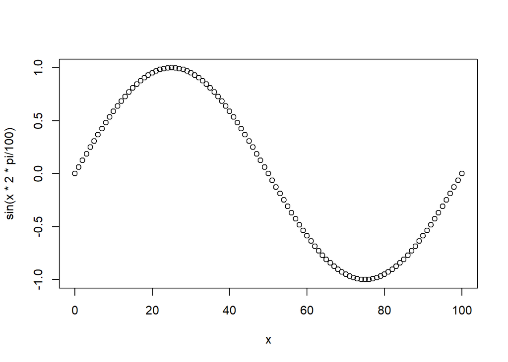

```r
plot(x,sin(x*2*pi/100))
```

## Editor

The **console** is for evaluating commands you don’t intend to keep or reuse. It’s useful for testing commands and poking around. The **environment** represents the state of a current session. The editor reads and writes files–it is where you head to compose your R scripts.

R scripts are simple text files that contain code you intend to run again and again; code to process data, perform analyses, produce visualizations, and even generate reports. The editor and console work together in the RStudio IDE, which gives you multiple ways to send parts of the script you are editing to the console for immediate evaluation.

Open up “worksheet.R” in the editor, and follow along by replacing the … placeholders with the code here. Then evalute just this line (Ctrl+Enter on Windows, ⌘+Enter on macOS)

```r
vals <-seq(1,100)
```

# Function documentation

How would you get to know these properties and the names of a function’s arguments?

```r
?seq
```

```
## starting httpd help server ... done
```

How would you even know what function to call?

```r
??sequence
```

## Directory

We’re going to load some data next. However, we want to ensure we know we are saving things in a proper location that we can come back to.

To check your working directory

```r
getwd()
```

```
## [1] "G:/My Drive/Teaching/DataScience/2021_Fall/Rwork"
```

To change/set your working directory use the function setwd() with your directory path in "" and using / between folder names

## Load Data (back to worksheet.R)

We will use the function read.csv() to load data from a Comma Separated Value (CSV) file. The essential argument for the function to read in data is the path to the file, other optional arguments adjust how the file is read.

Additional file types can be read in using read.table(); in fact, read.csv() is a simple wrapper for the read.table() function having set some default values for some of the optional arguments (e.g. sep = “,”).

Use the assignment operator “<-“ to read data into a variable for subsequent operations.

Type read.csv( into the editor and then press tab to see what arguments this function takes. Hovering over each item in the list will show a description of that argument from the help documentation about that function. Specify the values to use for an argument using the syntax name = value.

```r
storm <- read.csv('StormEvents.csv')
```

**Question** How does read.csv determine the field names? **Answer** The read.csv command assumes the first row in the file contains column names. Look at ?read.csv to see the default header = TRUE argument. What exactly that means is described down in the “Arguments” section.

Missing data, as interpreted by the read.csv function, is controlled by the na.strings argument. Override the default value of ‘NA’ with a character vector.

You often need to specify multiple strings to interpret as missing values, such as na.strings = c(“missing”, “no data”, “< 0.05 mg/L”, “XX”, “-9999”).

```r
storm <- read.csv(
  'StormEvents.csv',
  na.strings = c('NA', 'UNKNOWN'))
```

The data viewer, opened with the function View() or the spreadsheet icon in the Environment, is useful despite not being a full spreadsheet application.

```r
View(storm)
```

After reading in the “StormEvents.csv” file, you can explore what types of data are in each column with the str() function, short for “structure”.

```r
str(storm)
```

```
## 'data.frame':    100 obs. of  25 variables:
##  $ EVENT_ID         : int  5501658 5482479 5482480 5482481 5482482 5482324 5482325 5482326 5482327 5482328 ...
##  $ STATE            : Factor w/ 19 levels "ALASKA","ARKANSAS",..: 6 3 17 17 17 3 3 3 3 3 ...
##  $ STATE_FIPS       : int  18 8 49 49 49 8 8 8 8 8 ...
##  $ YEAR             : int  2006 2006 2006 2006 2006 2006 2006 2006 2006 2006 ...
##  $ MONTH_NAME       : Factor w/ 4 levels "April","February",..: 1 3 3 3 3 3 3 3 3 3 ...
##  $ EVENT_TYPE       : Factor w/ 14 levels "Avalanche","Coastal Flood",..: 11 4 4 4 4 14 14 13 14 14 ...
##  $ BEGIN_DATE_TIME  : Factor w/ 53 levels "1/1/2006 0:00",..: 53 1 1 1 1 45 45 43 42 43 ...
##  $ CZ_TIMEZONE      : Factor w/ 6 levels "AST","CST","CST-6",..: 2 5 5 5 5 5 5 5 5 5 ...
##  $ END_DATE_TIME    : Factor w/ 55 levels "1/1/2006 9:20",..: 55 48 48 48 48 47 47 42 44 43 ...
##  $ INJURIES_DIRECT  : int  0 0 0 0 0 0 0 0 0 0 ...
##  $ INJURIES_INDIRECT: int  0 0 0 0 0 0 0 0 0 0 ...
##  $ DEATHS_DIRECT    : int  0 0 0 0 0 0 0 0 0 0 ...
##  $ DEATHS_INDIRECT  : int  0 0 0 0 0 0 0 0 0 0 ...
##  $ DAMAGE_PROPERTY  : Factor w/ 6 levels "0","0.00K","200K",..: 5 NA NA NA NA NA NA NA NA NA ...
##  $ DAMAGE_CROPS     : Factor w/ 2 levels "0","0.00K": NA NA NA NA NA NA NA NA NA NA ...
##  $ SOURCE           : Factor w/ 14 levels "AMATEUR RADIO",..: 7 8 8 8 8 2 2 2 14 2 ...
##  $ MAGNITUDE        : num  61 NA NA NA NA NA NA NA NA NA ...
##  $ MAGNITUDE_TYPE   : Factor w/ 2 levels "EG","MG": 1 NA NA NA NA NA NA NA NA NA ...
##  $ BEGIN_LAT        : num  38.4 NA NA NA NA ...
##  $ BEGIN_LON        : num  -87.5 NA NA NA NA ...
##  $ END_LAT          : num  38.3 NA NA NA NA ...
##  $ END_LON          : num  -87.3 NA NA NA NA ...
##  $ EPISODE_NARRATIVE: Factor w/ 37 levels "3 CHICKEN HOUSES DESTROYED.",..: NA 36 35 35 35 7 7 37 13 8 ...
##  $ EVENT_NARRATIVE  : Factor w/ 6 levels "1.3 inches of rain fell in 30 minutes.",..: 2 NA NA NA NA NA NA NA NA NA ...
##  $ DATA_SOURCE      : Factor w/ 2 levels "CSV","PDS": 2 2 2 2 2 2 2 2 2 2 ...
```

## Data Structures

The str() function just showed us that our data is made up of one-dimensional data structures (columns).

There are two one-dimensional data structures you will regularly encounter.

- Lists
- Vectors

## Lists

Lists are one-dimensional and each element is entirely unrestricted; you can put anything in a list.

Create a list called x with a string, a sequence, and a function.

```r
x <- list('abc', 1:3, sin)
```

All data frames are actually lists, so our data frame storm is actually a list. We’ll get into more details later, but you can check this out with the function typeof().

```r
typeof(storm)
```

```
## [1] "list"
```

**Question** Compare the structure of storm and x while thinking about the length of each of their elements. Do the elements within list x have a length? The same length? **Answer** The elements of x all have lengths, and are not all the same. Note that the command length(‘abc’) yields 1.

When you enter a single number or character string in R, you are actually creating a one-dimensional data structure of length 1. There are not really 0-dimensional “scalars” in R. The kind of one-dimensional structure created in this is called a “vector”.

## Vectors

Vectors are one-dimensional but unlike lists, values must be of the same data type (e.g. integer, character, logical).

Create a vector by combining elements of the same type together using the concatenate function c().

Type ?c() in the console to learn more about this really common and useful function.

```r
c(1,2,3)
```

```
## [1] 1 2 3
```

All elements of a vector must be the same type, so when you attempt to combine different types they will be coerced to the most flexible type.

```r
c(1,2,'c')
```

```
## [1] "1" "2" "c"
```

The difference between c(1, 2, 3) and c(1, 2, ‘c’) isn’t just in the third element. To understand the difference, we need to recognize data types.

## Data Types

There are different kinds of data types you will encounter in R: double, integer, character, logical, factor

Both the double and integer data types are considered numeric, and while the str function tells you that a double is “num”, the typeof function will properly identify either numeric type.

Missing data created with NA actually have a variant for each data type. So you can put NA in any vector without breaking the rule that the elements of a vector have the same data type.

## Factors

Data of type factor is stored in a vector that can only contain predefined values of categorical data. Factors are similar to character vectors, but possess a levels attribute that assigns names to each level, or distinct value, in the vector.

Use factor() to create a vector with predefined values, which are often character strings.

```r
education <- factor(
    c('college', 'highschool', 'college', 'middle', 'middle'),
    levels = c('middle', 'highschool', 'college'))
```

The str function identifies this vector as being of data type “factor” and notes the labels for each level, but prints the integers assigned to the levels instead of the labels.

```r
str(education)
```

```
##  Factor w/ 3 levels "middle","highschool",..: 3 2 3 1 1
```

Factors can sometimes be tricky to work with in R. While factors can be useful for plotting data by categories, they can often get in the way of other calculations and analyses. It is good to know how to convert between data types with the functions as.character(), as.integer(), as.factor(), as.numeric().

## Data Frames

We mentioned above that a data frame is actually a list of vectors, but with a few important constraints. The vectors must all be of the same length, giving a rectangular data structure. Vectors must also each have a unique name (column name).

Use the dim() function to check the dimensions of our storm data frame.

```r
dim(storm)
```

```
## [1] 100  25
```

The column names are accessed by the names() function.

```r
names(storm)
```

```
##  [1] "EVENT_ID"          "STATE"             "STATE_FIPS"
##  [4] "YEAR"              "MONTH_NAME"        "EVENT_TYPE"
##  [7] "BEGIN_DATE_TIME"   "CZ_TIMEZONE"       "END_DATE_TIME"
## [10] "INJURIES_DIRECT"   "INJURIES_INDIRECT" "DEATHS_DIRECT"
## [13] "DEATHS_INDIRECT"   "DAMAGE_PROPERTY"   "DAMAGE_CROPS"
## [16] "SOURCE"            "MAGNITUDE"         "MAGNITUDE_TYPE"
## [19] "BEGIN_LAT"         "BEGIN_LON"         "END_LAT"
## [22] "END_LON"           "EPISODE_NARRATIVE" "EVENT_NARRATIVE"
## [25] "DATA_SOURCE"
```

Creating a data frame from scratch can be done by combining vectors with the data.frame() function. We created the education vector above. Now create a vector named income, and put the two vectors together to make a data frame.

```r
income <-c(32000, 28000, 89000, 0, 0)
df <- data.frame(education, income)
```

In summary, a data frame is the data structure most similar to a spreadsheet, with a few key differences:

- The columns must be equal-length vectors.
- As vectors, a column must hold values of the same type.
- Each column must have a unique name.

**Remember to use these functions when getting to know a data frame:** dim(), nrow(), ncol(), names(), str(), summary(), head(), tails()

## Matricies

The matrix is a two-dimensional data structure, and differs from a data frame in terms of the underlying data type. A matrix must be composed of elements of the same data type. You can check to see if you have a matrix by using the class() function.

When should you use a matrix vs. a data frame?

If your columns of data have different data types (e.g. integer, character, factor), you need to use a data frame.

If the analysis or functions you are using expect one structure or the other, you should use the expected data structure

## Parts and Subsets

Any single part of a data structure is always accessible, either by its name or by its position, using double square brackets: [[ and ]].

## Position

The first element:

```r
income[[1]]
```

```
## [1] 32000
```

The third element:

```r
income[[3]]
```

```
## [1] 89000
```

## Names

Parts of an object may also have a name. The names can be given when you are creating a vector or afterwards using the names() function.

```r
df[['education']]
```

```
## [1] college    highschool college    middle     middle
## Levels: middle highschool college
```

```r
names(df) <- c('ed', 'inc')
df[['ed']]
```

```
## [1] college    highschool college    middle     middle
## Levels: middle highschool college
```

**Question** This use of <- with names(x) on the left is a little odd. What’s going on? **Answer** We are overwriting an existing variable, but one that is accessed through the output of the function on the left rather than the global environment.

For a multi-dimensional array, separate the dimensions within which a part is requested with a comma.

```r
df[[3, 'ed']]
```

```
## [1] college
## Levels: middle highschool college
```

It’s fine to mix names and indices when selecting parts of an object.

The $ sign is an additional operator for quick access to a single, named part of some objects. It’s most useful when used interactively with “tab completion” on the columns of a data frame.

```r
df$ed
```

```
## [1] college    highschool college    middle     middle
## Levels: middle highschool college
```

## Subsets

Multiple parts of a data structure are similarly accessed using single square brackets: [ and ]. What goes between the brackets, to specify the positions or names of the desired subset, may be of multiple forms.

```r
days <- c(
  'Sunday', 'Monday', 'Tuesday',
  'Wednesday', 'Thursday', 'Friday',
  'Saturday')
weekdays <- days[2:6]
weekend <- days[c(1, 7)]
weekdays
```

```
## [1] "Monday"    "Tuesday"   "Wednesday" "Thursday"  "Friday"
```

```r
weekend
```

```
## [1] "Sunday"   "Saturday"
```

A logical test applied to a single column produces a vector of TRUE and FALSE values that’s the right length for subsetting the data.

```r
df[df$ed == 'college', ]
```

```
##        ed   inc
## 1 college 32000
## 3 college 89000
```

## Installing & Loading Packages

R packages are a collection of R functions, complied code and sample data. They are stored under a directory called “library” in the R environment. By default, R installs a set of packages during installation. More packages are added later, when they are needed for some specific purpose. The following command gets the packages directly from CRAN webpage (directory of R packages) and installs the package in the R environment.

install.packages(“tidyr”) #one package at a time

install.packages(“dplyr”,“ggplot2”) #multiple packages

Before a package can be used in the code, it must be loaded to the current R environment. You also need to load a package that is already installed previously but not available in the current environment. The library() function is the standard way to load packages in scripts. Inside functions the require() function is used instead as it will give a warning to the function user if required packages are not installed.